# Matriks

Qowim Musyafak (200605110137) / UIN Maulana Malik Ibrahim Malang TI-A Linear Algebra / Dosen Pembimbing Prof.Dr.Suhartono, M.Kom

04 April 2021

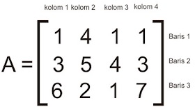

Berikut adalah cara membuat matriks pada pemrograman R dengan membuat fungsi matriks(), Pada matriks A didalamnya kita isi dengan data sebanyak 25, terdiri dari 1-25 yang mana terdapat baris yang ditunjukkan nrow=5 dan kolom ditunjukkan dengan ncol=5. Pada matriks B didalamnya kita isi dengan data sebanyak 25 juga, terdiri dari 25-49 yang mana juga terdapat baris yang ditunjukkan nrow=5 dan kolom ditunjukkan dengan ncol=5. Selanjutnya, dibawahnya adalah operasi - operasi dasar pada matriks A dan B.

Matriks A | matrix(data = 1:25, nrow = 5, ncol = 5, byrow = TRUE) |

```r
A <- matrix(data = 1:25, nrow = 5, ncol = 5, byrow = TRUE)
A
```

```
##      [,1] [,2] [,3] [,4] [,5]
## [1,]    1    2    3    4    5
## [2,]    6    7    8    9   10
## [3,]   11   12   13   14   15
## [4,]   16   17   18   19   20
## [5,]   21   22   23   24   25
```

Matriks B | (matrix(data = 25:49, nrow = 5, byrow = FALSE) |

```r
B <- matrix(data = 25:49, nrow = 5, byrow = FALSE)
B
```

```
##      [,1] [,2] [,3] [,4] [,5]
## [1,]   25   30   35   40   45
## [2,]   26   31   36   41   46
## [3,]   27   32   37   42   47
## [4,]   28   33   38   43   48
## [5,]   29   34   39   44   49
```

Operasi - operasi Pada Matriks

A. Operasi Penjumlahan

```r
A + B
```

```
##      [,1] [,2] [,3] [,4] [,5]
## [1,]   26   32   38   44   50
## [2,]   32   38   44   50   56
## [3,]   38   44   50   56   62
## [4,]   44   50   56   62   68
## [5,]   50   56   62   68   74
```

B. Operasi Pengurangan

```r
A - B
```

```
##      [,1] [,2] [,3] [,4] [,5]
## [1,]  -24  -28  -32  -36  -40
## [2,]  -20  -24  -28  -32  -36
## [3,]  -16  -20  -24  -28  -32
## [4,]  -12  -16  -20  -24  -28
## [5,]   -8  -12  -16  -20  -24
```

C. Operasi Perkalian

```r
A * B
```

```
##      [,1] [,2] [,3] [,4] [,5]
## [1,]   25   60  105  160  225
## [2,]  156  217  288  369  460
## [3,]  297  384  481  588  705
## [4,]  448  561  684  817  960
## [5,]  609  748  897 1056 1225
```

D. Operasi Pembagian

```r
A / B
```

```
##           [,1]       [,2]       [,3]      [,4]      [,5]
## [1,] 0.0400000 0.06666667 0.08571429 0.1000000 0.1111111
## [2,] 0.2307692 0.22580645 0.22222222 0.2195122 0.2173913
## [3,] 0.4074074 0.37500000 0.35135135 0.3333333 0.3191489
## [4,] 0.5714286 0.51515152 0.47368421 0.4418605 0.4166667
## [5,] 0.7241379 0.64705882 0.58974359 0.5454545 0.5102041
```

E. Operasi Eksponensial

```r
A ^ B
```

```
##              [,1]         [,2]         [,3]         [,4]         [,5]
## [1,] 1.000000e+00 1.073742e+09 5.003155e+16 1.208926e+24 2.842171e+31
## [2,] 1.705817e+20 1.577754e+26 3.245186e+32 1.330279e+39 1.000000e+46
## [3,] 1.310999e+28 3.418219e+34 1.644008e+41 1.372074e+48 1.889249e+55
## [4,] 5.192297e+33 4.025450e+40 5.015973e+47 9.691809e+54 2.814750e+62
## [5,] 2.209833e+38 4.389056e+45 1.280518e+53 5.361603e+60 3.155444e+68
```

Daftar Pustaka

1. https://rstudio-pubs-static.s3.amazonaws.com/99415_2b07b7f8b93d4d4ca79ade8bacc4f89d.html